# Llama

Tao Zou

2024-08-18

# RMSNorm

`RMSNorm` normalizes the input of each attention sub-layer in all transformer blocks, instead of normalizing the output like `LayerNorm`.

`RMSNorm` is an extension of `LayerNorm` and has less computational overhead of `LayerNorm`.

$$\begin{bmatrix}x^{(1)}_{11}&x^{(1)}_{12}&x^{(1)}_{13}&x^{(1)}_{14}\\x^{(1)}_{21}&x^{(1)}_{22}&x^{(1)}_{23}&x^{(1)}_{24}\end{bmatrix}\\
\begin{bmatrix}x^{(2)}_{11}&x^{(2)}_{12}&x^{(2)}_{13}&x^{(2)}_{14}\\x^{(2)}_{21}&x^{(2)}_{22}&x^{(2)}_{23}&x^{(2)}_{24}\end{bmatrix}$$

$$rms^{(k)}_i=\sqrt{\frac{1}{4}\sum^{4}_j\big{[}x_{ij}^{(k)}\big{]}^2+\epsilon}$$

, where $\epsilon$ is a very small number to avoid $rms$ being $0$.

update method:
$$[x_{i1}^{(k)},x_{i2}^{(k)},x_{i3}^{(k)},x_{i4}^{(k)}] =
\Big{[}\frac{x_{i1}^{(k)}}{rms_i^{(k)}}g_1,\frac{x_{i1}^{(k)}}{rms_i^{(k)}}g_2,\frac{x_{i1}^{(k)}}{rms_i^{(k)}}g_3,\frac{x_{i1}^{(k)}}{rms_i^{(k)}}g_4\Big{]}$$

, where $g_j$ is learnable scaling parameters.

```python
import torch
import torch.nn as nn

class RMSNorm(nn.Module):
    def __init__(self, d_model, eps=1e-8):
        super(RMSNorm, self).__init__()
        self.d_model = d_model
        self.eps = eps
        self.scale = nn.Parameter(torch.ones(d_model))

    def forward(self, x):
        rms = torch.sqrt(torch.mean(x ** 2, dim=-1, keepdim=True) + self.eps)
        x = x / rms * self.scale
        return x

X = torch.tensor([
        [[1, 2, 3, 4],
         [5, 6, 7, 8]],
        [[5, 6, 7, 8],
         [5, 1, 0, -1]]
    ], dtype=torch.float32)
with torch.no_grad():
  rmsnorm = RMSNorm(4)
  print(rmsnorm(X))
```

```
## tensor([[[ 0.3651,  0.7303,  1.0954,  1.4606],
##          [ 0.7581,  0.9097,  1.0613,  1.2130]],
##
##         [[ 0.7581,  0.9097,  1.0613,  1.2130],
##          [ 1.9245,  0.3849,  0.0000, -0.3849]]])
```

# SwiGLU

## Swish function

$$Swish(\vec{x};\beta)=\vec{x}\cdot\text{Sigmoid}(\beta\cdot\vec{x})$$

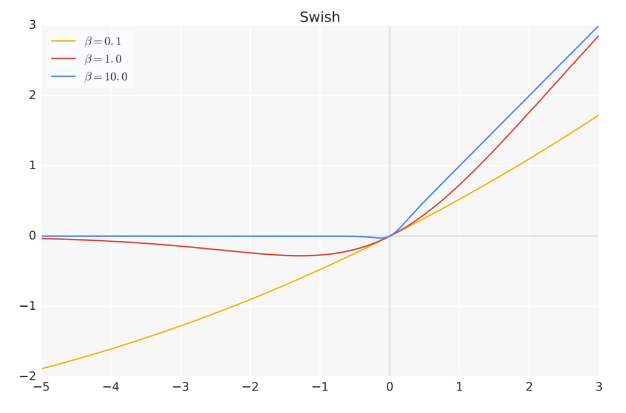

## GLU (Gated Linear Units)

$$GLU(\vec{x};\boldsymbol{W}_1,\boldsymbol{W}_2,b_1,b_2)=\text{Sigmoid}(\vec{x}\boldsymbol{W}_1+b_1)\odot(\vec{x}\boldsymbol{W}_2+b_2)$$

$\odot$ is Hadamard product. $\boldsymbol{W}_1$, $\boldsymbol{W}_2$, $b_1$, $b_2$ are learnable parameters.

## SwiGLU

$$SwiGLU=Swish(\vec{x}\boldsymbol{W}_1;
\beta)\odot(\vec{x}\boldsymbol{W}_2)$$

This SwiGLU function is used to replace ReLU function in Llama.

# RoPE

Rotary positional embeddings (RoPE) is used to learn the relative positional relationships between query and key in self-attention layers.

Suppose I have a series with $8$ tokens and $2$ hidden dims.

$$\color{red}{\vec{q}_2}
\mathop{\longleftarrow}^{W_q}
\begin{bmatrix}
x_{11}&x_{12}\\
\color{red}{x_{21}}&\color{red}{x_{22}}\\
\vdots&\vdots\\
x_{81}&x_{82}
\end{bmatrix}
\ \
\color{red}{\vec{k}_8}
\mathop{\longleftarrow}^{W_k}
\begin{bmatrix}
x_{11}&x_{12}\\
x_{21}&x_{22}\\
\vdots&\vdots\\
\color{red}{x_{81}}&\color{red}{x_{82}}
\end{bmatrix}$$

In Attention mechanism, $\vec{q}_2$ and $\vec{k}_8$ will be dot produected directly. But when using RoPE, $\vec{q}_2$ and $\vec{k}_8$ will be rotated first.

$$f(\vec{q}_2)=\vec{q}_2e^{i2\theta}=\big{(}q_2^{(1)}+iq_2^{(2)}\big{)}(\cos2\theta+i\sin2\theta)\\
f(\vec{k}_8)=\vec{k}_8e^{i8\theta}=\big{(}k_8^{(1)}+ik_8^{(2)}\big{)}(\cos8\theta+i\sin8\theta)$$

Then use the following function to calculate the rotary product.

$$\begin{bmatrix}q_2^{(1)}&q_2^{(2)}\end{bmatrix}
\begin{bmatrix}
\cos(2-8)\theta&-\sin(2-8)\theta\\
\sin(2-8)\theta&\cos(2-8)\theta
\end{bmatrix}
\begin{bmatrix}k_8^{(1)}\\k_8^{(2)}\end{bmatrix}$$

In general cases, hidden dims will be 4096 and more. So, for $\vec{q}_m$ and $\vec{k}_n$ will be include in the following formula.

$$\vec{q}_m^T
\begin{bmatrix}
\cos(m-n)\theta_0&-\sin(m-n)\theta_0&0&0&\cdots\\
\sin(m-n)\theta_0&\cos(m-n)\theta_0&0&0&\cdots\\
0&0&\cos(m-n)\theta_1&-\sin(m-n)\theta_1&\cdots\\
0&0&\sin(m-n)\theta_1&\cos(m-n)\theta_1&\cdots\\
\vdots&\vdots&\vdots&\vdots&\ddots
\end{bmatrix}
\vec{k}_n$$

In Llama, there will no longer be absolute positional embedding, the new replacement of which is RoPE in self-attention layers.

# Details of Llama of Different Size

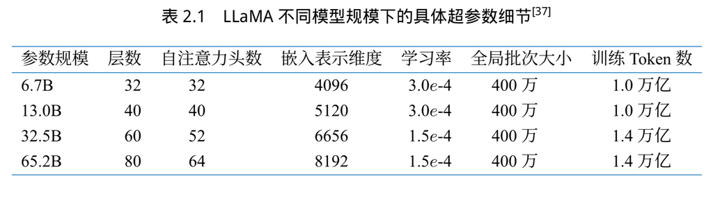

# Optimization of Attention Mechanism

Suppose I have a $n\times d$ matrix, $n$ is the sequence’s length and $d$ is the hidden nums. The time complexity of self-attention calculation is $O(n^2d)$.

Therefore, long sequence will cost huge computational resources.

## Sparse attention

### sparse attention based on position

The following graph shows basic types of position-based sparse attention: (1) Global Attention; (2) Band Attention; (3) Dilated Attention; (4) Random Attention; (5) Block Attention.

A node or a row/column in the graph represents a token.

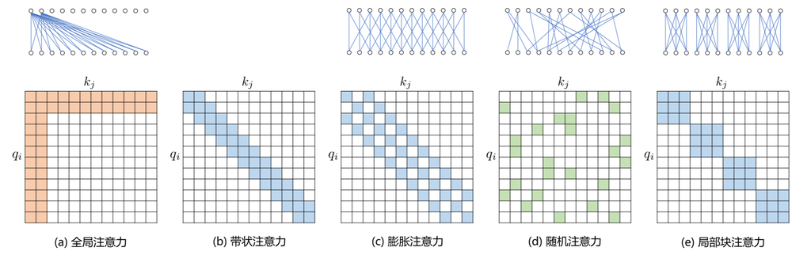

The following graph shows advanced types of position-based sparse attention: (1) Star-Transformer; (2) Longformer; (3) ETC; (4) BigBird.

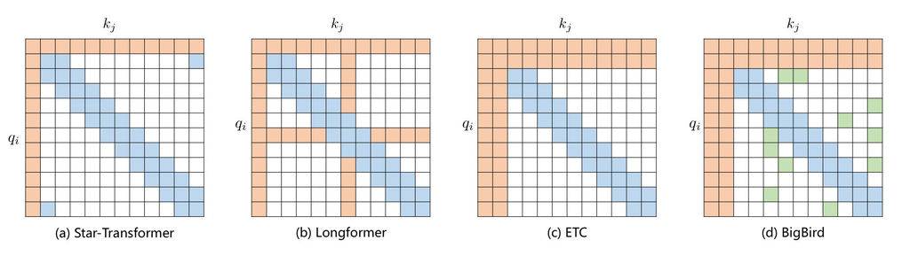

### sparse attention based on content

Routing Transformer: use k-means cluster to select keys for query. The keys must be in the same cluster with the query.

## FlashAttention

FlashAttention algorithm changes the calculation process on GPU to speed up self-attention calculation speed.

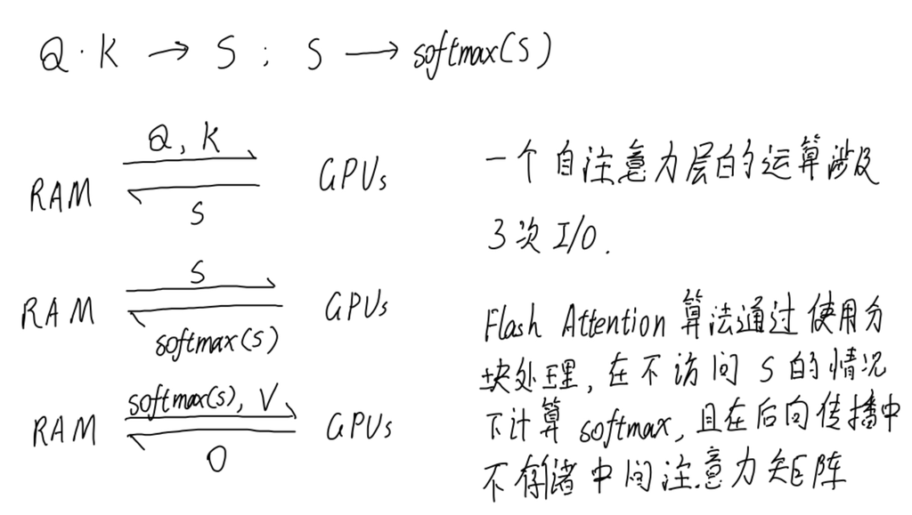

# Multi-Query Attention

Different heads of query share a single set of keys and values. MQA reduces the head number of key and value to 1, so that the parameters in self-attention layer are significantly reduced.

For example, in multi-head attention, the parameters of q,k,v is $28\times28\times3$ for $W_{q\ \ (28, 28)}$, $W_{k\ \ (28, 28)}$, $W_{v\ \ (28, 28)}=2,352$. In multi-query attention, the parameters of q,k,v is $28\times(28+2\times7)=1,176$, where $7$ is the dimension of a single head.

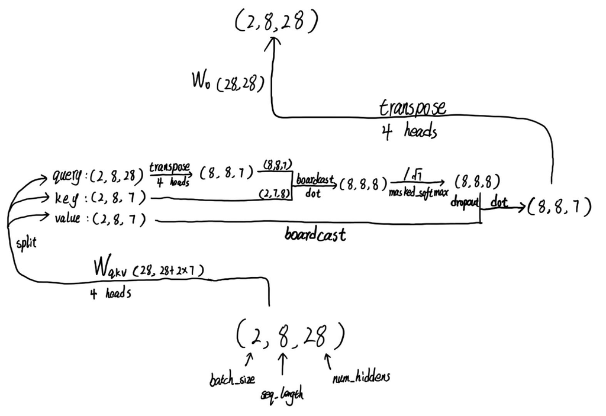

However, MQA may not work well because it reduces parameters dramatically. It is the fastest but lower in quality. MQA is used in ChatGLM2 and Google Gemini.

# Grouped-Query Attention

GQA is a compromise between MHA and MQA. GQA is used in Llama2, Mistral and Google gemma2. [GQA: Training Generalized Multi-Query Transformer Models from Multi-Head Checkpoints](https://arxiv.org/pdf/2305.13245)

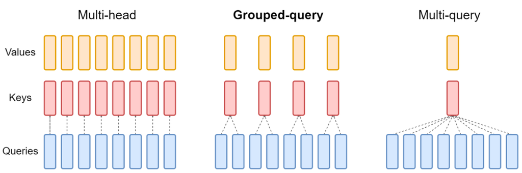